# Exploratory Analysis of Municipalities in Brazil that have adopted a Fare Free Public Transport

Thais Pereira

07/07/2023

## 1. General data about the municipalities

| Federative Unit | City | Population Class | GDP | GDP Per Capta Income | % of Poor | Social Prosperity | Urbanization Rate | Territorial Area | Demographic Density | Gini | Theil-L | Municipal Human Development Index (MHDI) | MHDI Education | MHDI Income | MHDI Longevidade | Social Vulnerability Index (SVI) | SVI Urban Infrastructure | SVI Human Capital | SVI Income and Work |
| --- | --- | --- | --- | --- | --- | --- | --- | --- | --- | --- | --- | --- | --- | --- | --- | --- | --- | --- | --- |
| Ceará | Aquiraz | 50.000 Up To 100.000 | 3411179.42 | 42147.15 | 0.2419 | Baixo | 0.923652035027813 | 480.236 | 169.876893860519 | 0.48 | 0.42 | Medium | Low | Medium | High | High | High | High | High |
| Ceará | Caucaia | 100.000 Up To 500.000 | 7257970.705 | 19873.31 | 0.2282 | Baixo | 0.891774545923839 | 1223.246 | 301.589377770293 | 0.48 | 0.41 | Medium | Medium | Medium | Very High | High | High | High | Medium |
| Ceará | Eusébio | 50.000 Up To 100.000 | 3184375.159 | 58604.18 | 0.2203 | Alto | 1 | 78.818 | 698.254205892055 | 0.65 | 0.79 | High | Medium | High | High | Medium | Low | High | Medium |
| Minas Gerais | Abaeté | 20.000 Up To 50.000 | 555813.549 | 23905.96 | 0.0669 | Alto | 0.868400176289114 | 1817.067 | 12.8024998527847 | 0.54 | 0.54 | Medium | Low | High | Very High | Low | Low | Medium | Medium |
| Minas Gerais | Arceburgo | 10.000 Up To 20.000 | 320228.103 | 29424.62 | 0.0294 | Alto | 0.860132506046903 | 162.875 | 67.4750575594781 | 0.38 | 0.24 | Medium | Low | Medium | Very High | Low | Very Low | Medium | Low |
| Minas Gerais | Arcos | 20.000 Up To 50.000 | 1525021.615 | 37766.76 | 0.0434 | Muito Alto | 0.927972238161598 | 509.873 | 79.7414258060341 | 0.43 | 0.32 | High | Medium | High | Very High | Very Low | Very Low | Low | Low |
| Minas Gerais | Caeté | 20.000 Up To 50.000 | 911463.359 | 20233.61 | 0.0992 | Alto | 0.86959509202454 | 542.531 | 83.6154984692119 | 0.46 | 0.37 | High | Medium | Medium | Very High | Medium | High | Low | Low |
| Minas Gerais | Campo Belo | 50.000 Up To 100.000 | 1118422.671 | 20640.44 | 0.0673 | Muito Alto | 0.943388173211237 | 528.225 | 102.869042548157 | 0.47 | 0.39 | High | Low | High | Very High | Low | Very Low | Low | Low |
| Minas Gerais | Cláudio | 20.000 Up To 50.000 | 809658.106 | 28055.65 | 0.045 | Muito Alto | 0.820845136005588 | 630.706 | 46.1276727984195 | 0.4 | 0.29 | High | Medium | High | Very High | Very Low | Very Low | Low | Low |
| Minas Gerais | Itatiaiuçu | 10.000 Up To 20.000 | 1855350.995 | 164890.77 | 0.0745 | Alto | 0.626611603545528 | 295.145 | 38.4692269901235 | 0.4 | 0.29 | Medium | Low | Medium | Very High | Low | Very Low | Medium | Medium |

[output cut: 53 more lines]

## 2. Localization of municipalities

The map below shows us more detailed the location of the cities

[interactive chart not shown]

## 3. Region of municipalities

| Region | Municipalities with Tarifa Zero |
| --- | --- |
| Centro-Oeste | 5 |
| Nordeste | 3 |
| Sudeste | 43 |
| Sul | 12 |

## 4. State of municipalities

| Federative Unit | Municipalities with Tarifa Zero |
| --- | --- |
| São Paulo | 20 |
| Minas Gerais | 17 |
| Paraná | 9 |
| Rio de Janeiro | 5 |
| Goiás | 4 |
| Ceará | 3 |
| Rio Grande do Sul | 2 |
| Espírito Santo | 1 |
| Mato Grosso do Sul | 1 |
| Santa Catarina | 1 |

## 5. Population Class

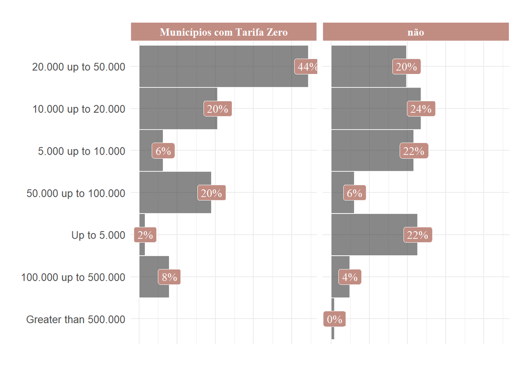

## 4. Year of Implementation

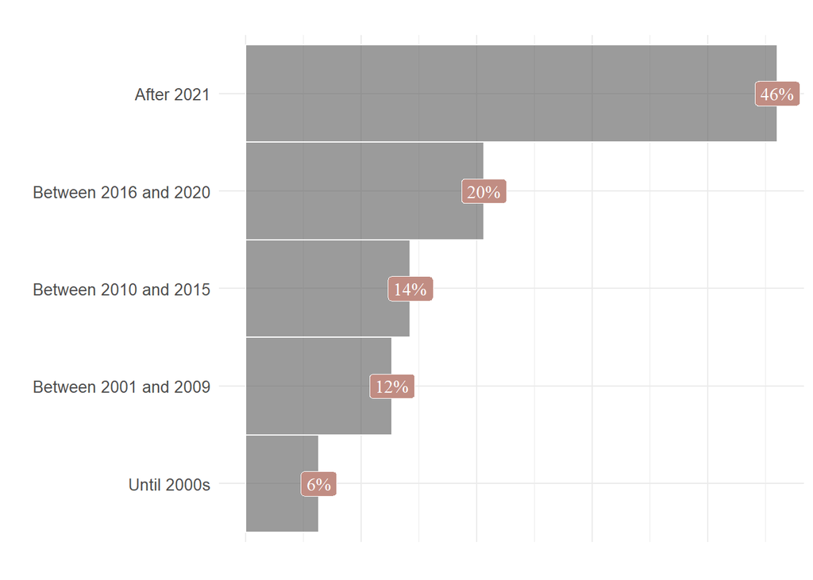

## 1.Análise da Teoria do Eleitor Mediano

**1° Premissa:** “Quanto maior a desigualdade, maior a exigência por serviços públicos e consequente aumento do gasto público. Portanto, cidades com tarifa zero devem ser mais desiguais do que cidades sem essa política.”

Para verificar se essa premissa de fato pode nos ajudar a explicar a tarifa zero, vejamos primeiro o Gini e o Theil-L, ambos são índices de desigualdade amplamente utilizados, medem o grau de concentração de renda em determinado grupo e variam de 0 a 1, sendo 0 uma situação de completa igualdade e 1 uma situação de completa desigualdade, nesse caso estão usando dados do censo de 2010.

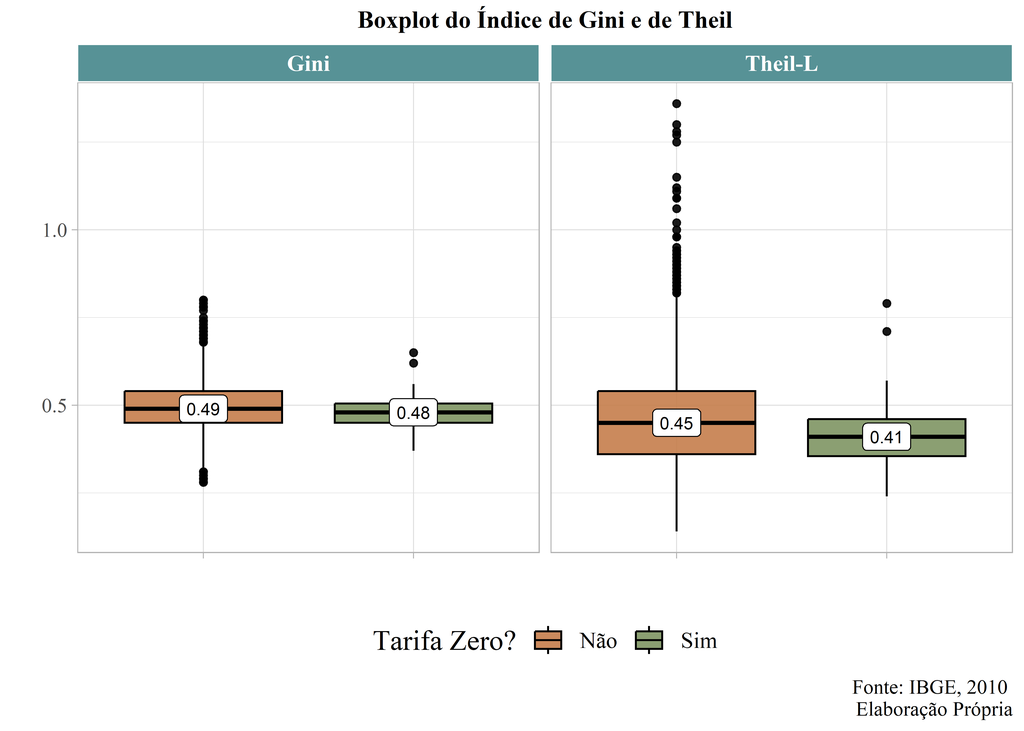

Tabela Separandos os valores por UF:

| Região | Cidades sem Tarifa Zero | Cidades com Tarifa Zero | Cidades sem Tarifa Zero | Cidades com Tarifa Zero |
| --- | --- | --- | --- | --- |
| Centro-Oeste | 0.49 | 0.51 | 0.42 | 0.46 |
| Nordeste | 0.52 | 0.48 | 0.52 | 0.42 |
| Norte | 0.56 | NA | 0.56 | NA |
| Sudeste | 0.46 | 0.47 | 0.39 | 0.4 |
| Sul | 0.46 | 0.48 | 0.38 | 0.415 |

Fonte: IBGE, 2010

**2° Premissa:** “Quanto menor a riqueza medida através do PIB, maior a demanda por políticas redistributivas. Dessa forma, cidades com tarifa zero dispõem de menor PIB per capita do que cidades sem essa política.”

Para essa análise fizemos um corte comparando apenas as cidades com até 150 mil reais de PIB per capta, tanto com tarifa zero quanto sem tarifa zero. Isso não significa retirar muitas cidades da base de dados já que 99,45% das cidades sem tarifa zero (e com menos de 300 mil habitantes) estão dentro desse valor de PIB per capita, no caso das cidades com tarifa zero, isso representa 96,4% das cidades, essa foi uma forma de retirar os valores discrepantes da análise e torná-la mais evidente.

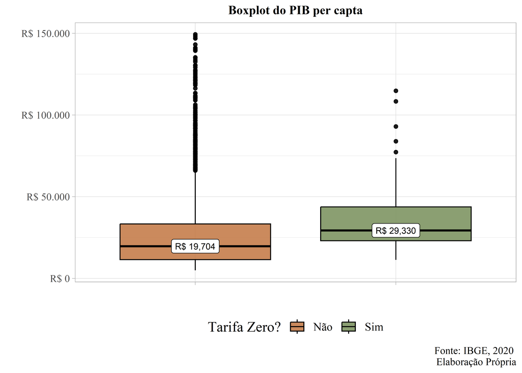

Tabela Separandos os valores por UF:

| Região | Cidades sem Tarifa Zero | Cidades com Tarifa Zero |
| --- | --- | --- |
| Centro-Oeste | 30219.75 | 22638.85 |
| Nordeste | 10522.78 | 42147.15 |
| Norte | 15738.68 | NA |
| Sudeste | 22080.28 | 29424.62 |
| Sul | 35401 | 29217.605 |

**3° premissa** Trabalhadores informais são mais favoráveis à política pois não usufruem da política de vale transporte limitada à trabalhadores formais, por isso nas cidades com tarifa zero há mais trabalhadores informais do que formais.

**4° premissa** Quanto maior a competitividade das eleições anteriores a adoção da política maior a pressão do eleitor mediano por políticas sociais. Se essa premissa for verdadeira, esperamos encontrar menor diferença média na quantidade de votos recebidos pelo prefeito e o candidato em 2° lugar nas eleições anteriores à adoção da política nas cidades com tarifa zero

```
## # A tibble: 2 × 2
##   tarifa_zero mediana
##   <chr>         <dbl>
## 1 nao            11.5
## 2 sim            14.8
```

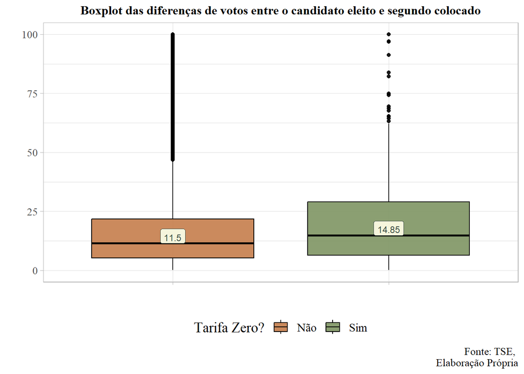

## 2. Teoria das Capacidades Estatais

**1° premissa:** Cidades que implementam políticas redistributivas dispõem de mais recursos e melhor capacidade administrativa. Por isso cidades com tarifa zero devem possuir mais secretarias exclusivas do que cidades sem essa política

Tabela 11: Caracterização do Orgão Gestor

| Caracterização do orgão gestor | Cidades sem Tarifa Zero | Cidades com Tarifa Zero |
| --- | --- | --- |
| Não informou | 2% | 0% |
| Secretaria exclusiva | 15% | 8% |
| Secretaria não exclusiva | 83% | 92% |

Fonte: IBGE, 2021

**2° premissa:**Cidades que implementam políticas redistributivas dispõem de mais recursos e melhor capacidade administrativa. Por isso cidades com tarifa zero possuem gestores com mais qualificação acadêmica.

Tabela 12: Escolaridade do Titular do Orgão Gestor

| Escolaridade | Cidades sem Tarifa Zero | Cidades com Tarifa Zero |
| --- | --- | --- |
| Ensino médio (2º Grau) completo | 49% | 24% |
| Ensino superior completo | 38% | 49% |
| Especialização | 11% | 19% |
| Mestrado | 1% | 8% |
| Doutorado | 0% | 0% |

Fonte: IBGE, 2021

**3° premissa:** Cidades que implementam políticas redistributivas dispõem de mais recursos e melhor capacidade administrativa. Por isso cidades com tarifa zero dispõem de maior quantidade de conselhos de transporte público em relação à cidades sem a política

Tabela 13: Existência de Conselho Municipal de Transporte

| Existe Conselho na Cidade? | Cidades sem Tarifa Zero | Cidades com Tarifa Zero |
| --- | --- | --- |
| Não ou não informou | 90% | 75% |
| Sim | 10% | 25% |

Fonte: IBGE, 2021

**4° premissa:** Cidades que implementam políticas redistributivas dispõem de mais recursos e melhor capacidade administrativa. Por isso cidades com tarifa zero dispõem de Fundo Municipal de Transporte em relação à cidades sem a política

Tabela 14: Existência de Fundo Municipal de Transporte

| Existe Fundo Municipal? | Cidades sem Tarifa Zero | Cidades com Tarifa Zero |
| --- | --- | --- |
| Não ou não informou | 94% | 86% |
| Sim | 6% | 14% |

Fonte: IBGE, 2021

**5° premissa:** Cidades que implementam políticas redistributivas dispõem de mais recursos e melhor capacidade administrativa. Por isso cidades com tarifa zero dispõem de Plano de Mobilidade Urbana em mais cidades do que em relação à cidades sem a política

Tabela 15: Existência de Plano de Mobilidade Urbana

| Existe Plano de Mobilidade Urbana? | Cidades sem Tarifa Zero | Cidades com Tarifa Zero |
| --- | --- | --- |
| Não ou não respondeu | 94% | 79% |
| Sim | 6% | 21% |

Fonte: IBGE, 2021

**6° premissa:** Cidades que implementam políticas redistributivas dispõem de mais recursos e melhor capacidade administrativa. Por isso cidades com tarifa zero dispõem de maior “Prosperidade Social” indicador definido pelo IPEA

Tabela 16: Índice de Prosperidade Social

| Índice de Prosperidade Social | Cidades sem Tarifa Zero | Cidades com Tarifa Zero |
| --- | --- | --- |
| Muito Alto | 30% | 63% |
| Alto | 16% | 22% |
| Baixo | 14% | 5% |
| Muito Baixo | 24% | 0% |
| Médio | 17% | 10% |

Fonte: IPEA, 2010

**7° premissa:** Cidades que implementam políticas redistributivas dispõem de mais recursos e melhor capacidade administrativa. Verificar a quantidade de funcionários estatutários dos municípios da administração direta - Carreira estável e recrutamento baseado no mérito produz capacidade estatal para adoção de políticas urbanas

Tabela 17: Regime de Contratação dos Funcionários da Administração Direta

| Regime de Contratação | Cidades sem Tarifa Zero | Cidades com Tarifa Zero |
| --- | --- | --- |
| Celetistas | 0.0 | 0 |
| Comissionados | 51.0 | 78 |
| Estagiarios | 0.0 | 24 |
| Estatutarios | 301.5 | 669 |
| Sem vinculo Permanente | 70.0 | 51 |

Fonte: IBGE, 2021

## 3.Análise da Difusão de Políticas Publicas

**1° premissa:**Verificar o padrão de difusão nas cidades que se sabe o ano da implementação - Políticas sociais primeiro se espalham na região onde surgiram e depois vão se difundindo para outras partes do país. Dessa forma, esperamos encontrar um padrão de difusão.

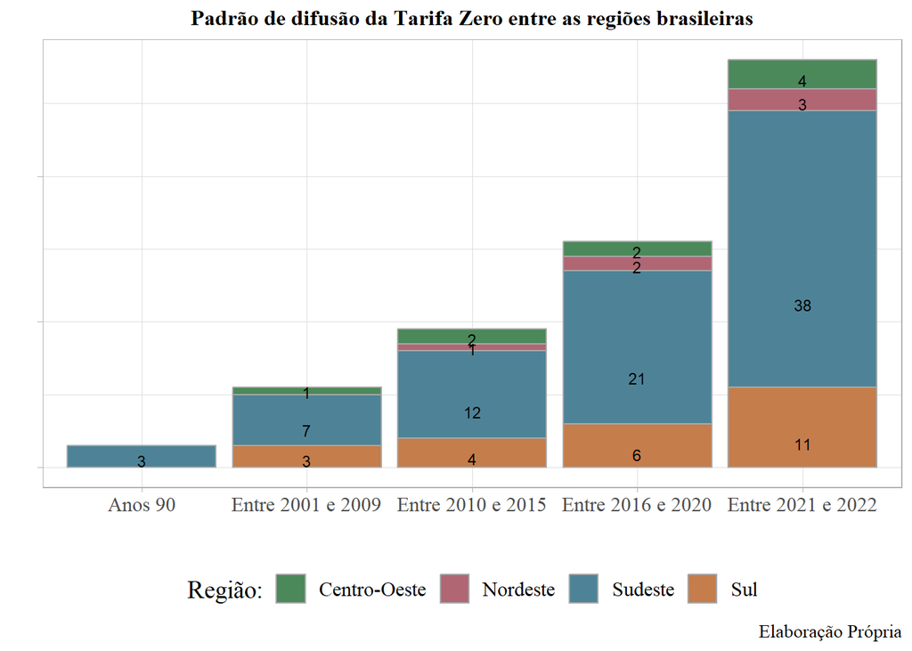

**2° premissa:** Verificar se as cidades que implementaram primeiro são maiores do que aquelas que adotaram depois, dessa forma pode-se observar se houve imitação de cidades menores em relação às maiores

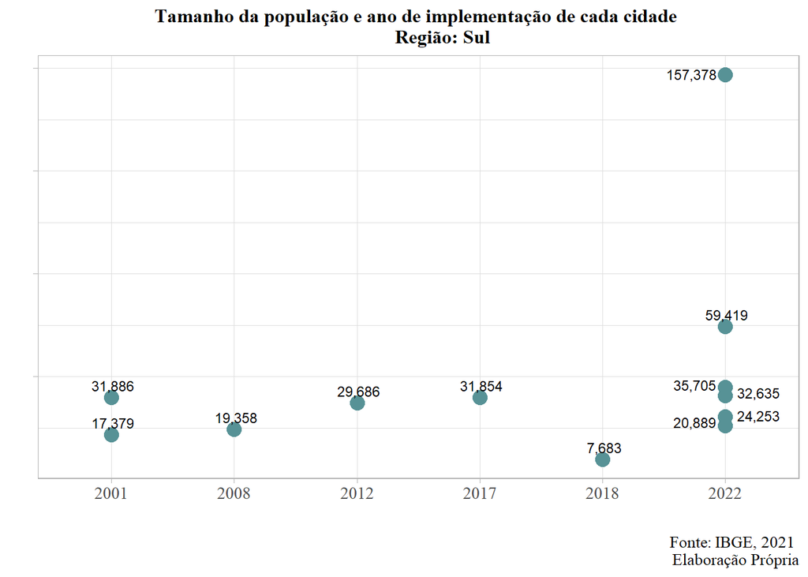

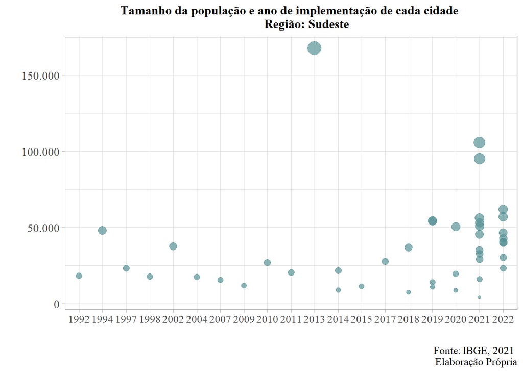

Todas as cidades brasileiras:

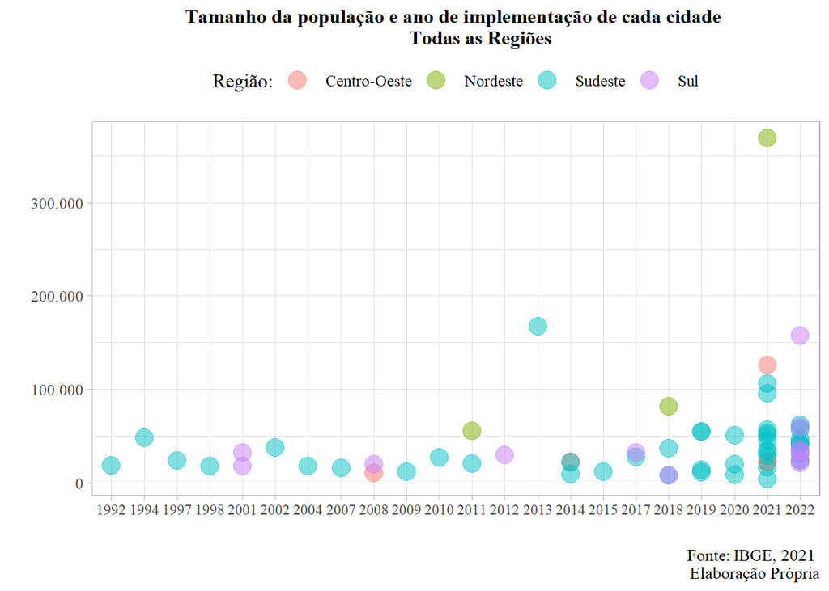

## 2. Teoria dos Multilplos Fluxos

**1° premissa:**Verificar a proximidade temporal entre debate nacional (Jornadas de Junho de 2013 e Pandemia de Covid-19) e adoção da tarifa zero pelos municípios e se nas entrevistas esses eventos são citados - Humor nacional - fluxo das soluções.

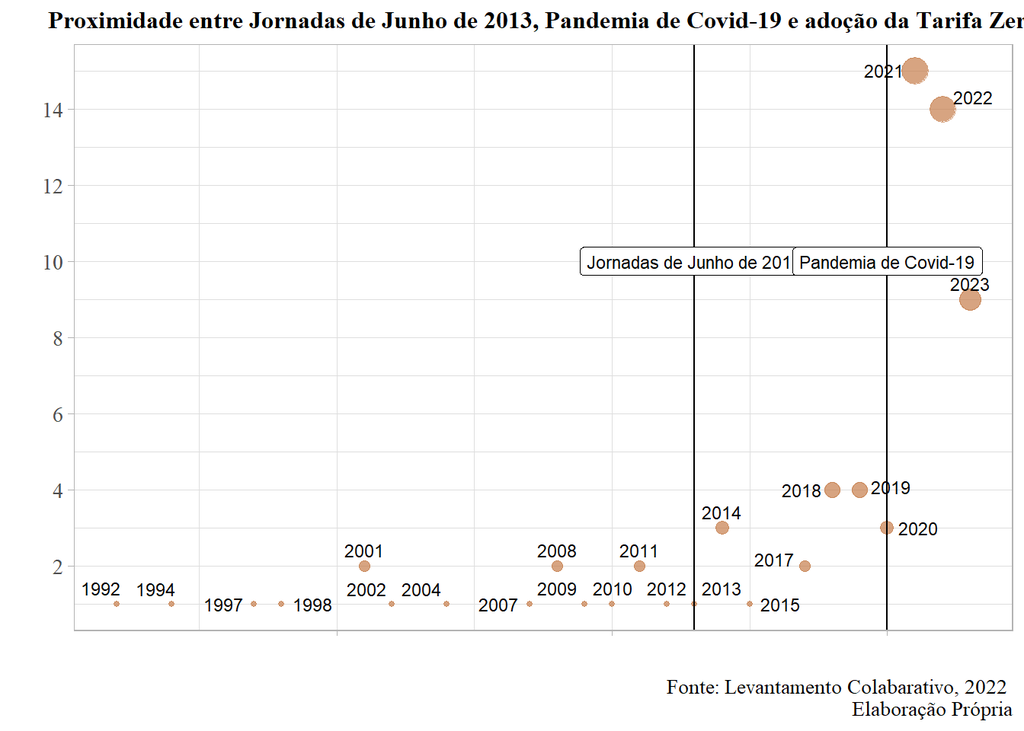

**2° premissa:**Verificar se houve uma mudança partidária nas eleições para prefeito anterior a adoção da política, e nas cidades em que houve essa mudança verificar se houve também mudança de expectro ideológico do partido - Mudanças no governo propiciam a adoção de novas políticas públicas

| Nome do Município | Partido do Prefeito Anterior | Partido do Prefeito que Implementou a Política | Houve mudança Partidária? |
| --- | --- | --- | --- |
| Euzebio | PSB | PSB | Não |
| Marica | PT | PT | Não |
| Pirapora Do Bom Jesus | PMDB | PMDB | Não |
| Sao Joaquim De Bicas | DEM | DEM | Não |
| Ouro Branco | PSDB | PSDB | Não |
| Santana Do Deserto | DEM | DEM | Não |
| Assis | PDT | PDT | Não |
| Tiete | PSDB | PSDB | Não |
| Goias | PT | PT | Não |
| Parobe | PDT | PDT | Não |

[output cut: 42 more lines]

Tabela Resumindo se houve mudança partidária

Tabela 18: Mudança Partidária nos municípios que adotaram tarifa zero

| Houve mudança Partidária? | Total Percentual |
| --- | --- |
| Não | 19% |
| Sim | 81% |

Fonte: TSE

Para as Cidades em que houve mudança partidária, houve mudança ideológica?

| Nome do Município | Partido do Prefeito Anterior | Partido do Prefeito que Implementou a Política | Houve mudança Ideológica? |
| --- | --- | --- | --- |
| Sao Joao Da Barra | Centro | Centro | Não |
| Guararema | Direita | Direita | Não |
| Aruana | Direita | Extrema Direita | Sim |
| Muzambinho | Direita | Centro | Sim |
| Ilha Solteira | Extrema Direita | Centro | Sim |
| Holambra | Direita | Centro Esquerda | Sim |
| Pitanga | Centro Direita | Direita | Sim |
| Wenceslau Braz | Centro | Esquerda | Sim |
| Itatiaiucu | Centro Esquerda | Esquerda | Sim |
| Silva Jardim | Esquerda | Direita | Sim |

[output cut: 32 more lines]

Tabela 18: Mudança Ideológica nos municípios em que houve mudança partidária

| Houve mudança Ideológica? | Total Percentual |
| --- | --- |
| Não | 5% |
| Sim | 95% |

Fonte: TSE

Das cidades que mudaram de partido e de espectro político, qual a proporção de cada direcionamento político?

Tabela 19: Mudança Ideológica nos municípios em que houve mudança partidária

| Espectro Ideológico | Percentual Governo Anterior | Percentual Governo que Implementou |
| --- | --- | --- |
| Centro | 22% | 40% |
| Centro Direita | 20% | 21% |
| Centro Esquerda | 10% | 2% |
| Direita | 22% | 14% |
| Esquerda | 20% | 14% |
| Extrema Direita | 5% | 7% |

Fonte: TSE